# Data Cleaning: Removing NaN Values and Duplicates

# Preliminary Data Exploration

```python
#Sort apps based on the highest rating
df_apps_clean.sort_values('Rating', ascending=False).head(9)
```

|  | App | Category | Rating | Reviews | Size_MBs | Installs | Type | Price | Content_Rating | Genres |
| --- | --- | --- | --- | --- | --- | --- | --- | --- | --- | --- |
| 21 | KBA-EZ Health Guide | MEDICAL | 5.00 | 4 | 25.00 | 1 | Free | 0 | Everyone | Medical |
| 1230 | Sway Medical | MEDICAL | 5.00 | 3 | 22.00 | 100 | Free | 0 | Everyone | Medical |
| 1227 | AJ Men's Grooming | LIFESTYLE | 5.00 | 2 | 22.00 | 100 | Free | 0 | Everyone | Lifestyle |
| 1224 | FK Dedinje BGD | SPORTS | 5.00 | 36 | 2.60 | 100 | Free | 0 | Everyone | Sports |
| 1223 | CB VIDEO VISION | PHOTOGRAPHY | 5.00 | 13 | 2.60 | 100 | Free | 0 | Everyone | Photography |
| 1222 | Beacon Baptist Jupiter, FL | LIFESTYLE | 5.00 | 14 | 2.60 | 100 | Free | 0 | Everyone | Lifestyle |
| 1214 | BV Mobile Apps | PRODUCTIVITY | 5.00 | 3 | 4.80 | 100 | Free | 0 | Everyone | Productivity |
| 2680 | Florida Wildflowers | FAMILY | 5.00 | 5 | 69.00 | 1,000 | Free | 0 | Everyone | Education |
| 1206 | ADS-B Driver | TOOLS | 5.00 | 2 | 6.30 | 100 | Paid | $1.99 | Everyone | Tools |

```python
#Sort apps based on the Size_MBs (Highest to Lowest)
df_apps_clean.sort_values('Size_MBs', ascending=False).head(9)
```

|  | App | Category | Rating | Reviews | Size_MBs | Installs | Type | Price | Content_Rating | Genres |
| --- | --- | --- | --- | --- | --- | --- | --- | --- | --- | --- |
| 9942 | Talking Babsy Baby: Baby Games | LIFESTYLE | 4.00 | 140995 | 100.00 | 10,000,000 | Free | 0 | Everyone | Lifestyle;Pretend Play |
| 10687 | Hungry Shark Evolution | GAME | 4.50 | 6074334 | 100.00 | 100,000,000 | Free | 0 | Teen | Arcade |
| 9943 | Miami crime simulator | GAME | 4.00 | 254518 | 100.00 | 10,000,000 | Free | 0 | Mature 17+ | Action |
| 9944 | Gangster Town: Vice District | FAMILY | 4.30 | 65146 | 100.00 | 10,000,000 | Free | 0 | Mature 17+ | Simulation |
| 3144 | Vi Trainer | HEALTH_AND_FITNESS | 3.60 | 124 | 100.00 | 5,000 | Free | 0 | Everyone | Health & Fitness |
| 9945 | Ultimate Tennis | SPORTS | 4.30 | 183004 | 100.00 | 10,000,000 | Free | 0 | Everyone | Sports |
| 7926 | Post Bank | FINANCE | 4.50 | 60449 | 100.00 | 1,000,000 | Free | 0 | Everyone | Finance |
| 7927 | The Walking Dead: Our World | GAME | 4.00 | 22435 | 100.00 | 1,000,000 | Free | 0 | Teen | Action |
| 7928 | Stickman Legends: Shadow Wars | GAME | 4.40 | 38419 | 100.00 | 1,000,000 | Paid | $0.99 | Everyone 10+ | Action |

```python
#Sort apps based on the Reviews (Highest to Lowest)
df_apps_clean.sort_values('Reviews', ascending=False).head(20)
```

|  | App | Category | Rating | Reviews | Size_MBs | Installs | Type | Price | Content_Rating | Genres |
| --- | --- | --- | --- | --- | --- | --- | --- | --- | --- | --- |
| 10805 | Facebook | SOCIAL | 4.10 | 78158306 | 5.30 | 1,000,000,000 | Free | 0 | Teen | Social |
| 10785 | WhatsApp Messenger | COMMUNICATION | 4.40 | 69119316 | 3.50 | 1,000,000,000 | Free | 0 | Everyone | Communication |
| 10806 | Instagram | SOCIAL | 4.50 | 66577313 | 5.30 | 1,000,000,000 | Free | 0 | Teen | Social |
| 10784 | Messenger – Text and Video Chat for Free | COMMUNICATION | 4.00 | 56642847 | 3.50 | 1,000,000,000 | Free | 0 | Everyone | Communication |
| 10650 | Clash of Clans | GAME | 4.60 | 44891723 | 98.00 | 100,000,000 | Free | 0 | Everyone 10+ | Strategy |
| 10744 | Clean Master- Space Cleaner & Antivirus | TOOLS | 4.70 | 42916526 | 3.40 | 500,000,000 | Free | 0 | Everyone | Tools |
| 10835 | Subway Surfers | GAME | 4.50 | 27722264 | 76.00 | 1,000,000,000 | Free | 0 | Everyone 10+ | Arcade |
| 10828 | YouTube | VIDEO_PLAYERS | 4.30 | 25655305 | 4.65 | 1,000,000,000 | Free | 0 | Teen | Video Players & Editors |
| 10746 | Security Master - Antivirus, VPN, AppLock, Boo... | TOOLS | 4.70 | 24900999 | 3.40 | 500,000,000 | Free | 0 | Everyone | Tools |
| 10584 | Clash Royale | GAME | 4.60 | 23133508 | 97.00 | 100,000,000 | Free | 0 | Everyone 10+ | Strategy |
| 10763 | Candy Crush Saga | GAME | 4.40 | 22426677 | 74.00 | 500,000,000 | Free | 0 | Everyone | Casual |
| 10770 | UC Browser - Fast Download Private & Secure | COMMUNICATION | 4.50 | 17712922 | 40.00 | 500,000,000 | Free | 0 | Teen | Communication |
| 10735 | Snapchat | SOCIAL | 4.00 | 17014787 | 5.30 | 500,000,000 | Free | 0 | Teen | Social |
| 10489 | 360 Security - Free Antivirus, Booster, Cleaner | TOOLS | 4.60 | 16771865 | 3.40 | 100,000,000 | Free | 0 | Everyone | Tools |
| 10731 | My Talking Tom | GAME | 4.50 | 14891223 | 36.00 | 500,000,000 | Free | 0 | Everyone | Casual |
| 10594 | 8 Ball Pool | GAME | 4.50 | 14198297 | 52.00 | 100,000,000 | Free | 0 | Everyone | Sports |
| 10302 | DU Battery Saver - Battery Charger & Battery Life | TOOLS | 4.50 | 13479633 | 14.00 | 100,000,000 | Free | 0 | Everyone | Tools |
| 10354 | BBM - Free Calls & Messages | COMMUNICATION | 4.30 | 12842860 | 3.50 | 100,000,000 | Free | 0 | Everyone | Communication |
| 10549 | Cache Cleaner-DU Speed Booster (booster & clea... | TOOLS | 4.50 | 12759663 | 15.00 | 100,000,000 | Free | 0 | Everyone | Tools |
| 10757 | Twitter | NEWS_AND_MAGAZINES | 4.30 | 11667403 | 6.30 | 500,000,000 | Free | 0 | Mature 17+ | News & Magazines |

# Create Pie and Donut Charts

We will use: - plotly - a commonly used data visualisation library that you can use in combination with or instead of Matplotlib.

```python
#Counting the number of entries from each Content_rating
ratings = df_apps_clean.Content_Rating.value_counts()
ratings
```

```
Everyone           6621
Teen                912
Mature 17+          357
Everyone 10+        305
Adults only 18+       3
Unrated               1
Name: Content_Rating, dtype: int64
```

```python
#Importing the data visualisation libraries
import pandas as pd
import plotly.express as px
```

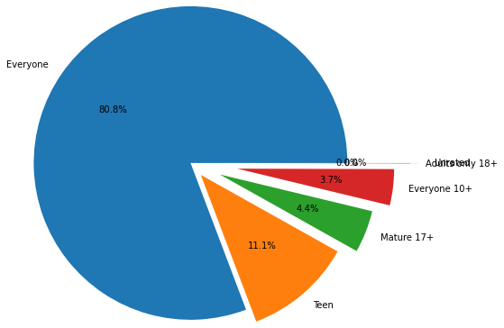

```python
%matplotlib inline
import matplotlib.pyplot as plt

ratings.plot(kind='pie', ylabel="", autopct = '%1.1f%%',radius = 2, explode = [0,0.2,0.4,0.6,0.8,0.9]) # we enter in #kind=pie to show matplotlib that we want a piechart.
plt.show()
```

If you’d like to configure other aspects of the chart, that you can’t see in the list of parameters, you can call a method called .update_traces(). In plotly lingo, “traces” refer to graphical marks on a figure. Think of “traces” as collections of attributes. Here we update the traces to change how the text is displayed.

# To create a donut 🍩 chart

```python
fig = px.pie(labels=ratings.index,values=ratings.values,title="Content Rating",names=ratings.index,hole=0.6,)

fig.update_traces(textposition='inside', textfont_size=15, textinfo='percent')

fig.show()
```

[interactive chart not shown]

# Modifying the datatype of particular columns

```python
#Installs data type is not coming up as a number. But rather coming up as an object.
#The reason Python is not recognising our installs as numbers is because of the comma (,) characters in the Installs column.
df_apps_clean.Installs.describe()
```

```
count          8199
unique           19
top       1,000,000
freq           1417
Name: Installs, dtype: object
```

We can remove the comma (,) character - or any character for that matter - from a DataFrame using the string’s .replace() method. Here we’re saying: “replace the , with an empty string”. This completely removes all the commas in the Installs column. We can then convert our data to a number using .to_numeric().

```python
df_apps_clean.Installs = df_apps_clean.Installs.astype(str).str.replace(',', "")
#removes the comma from the numbers in the installs column and replaces it with an empty/blank string.
```

```python
df_apps_clean.Installs = pd.to_numeric(df_apps_clean.Installs)
#convert the data in Installs column into a number
```

```python
#The price is showing as an object rather than a number data type, so we need to change it.

df_apps_clean.Price.describe()
```

```
count     8199
unique      73
top          0
freq      7595
Name: Price, dtype: object
```

```python
#We use replace method to filter out the dollar sign from all the entries in the Price column.
df_apps_clean.Price = df_apps_clean.Price.astype(str).str.replace('$', "")
```

```python
#After removing the dollar sign from the entries in the Price column, we then change price column to a number or float data type

df_apps_clean.Price = pd.to_numeric(df_apps_clean.Price)
```

```python
df_apps_clean.Price.describe()
```

```
count   8,199.00
mean        1.04
std        16.85
min         0.00
25%         0.00
50%         0.00
75%         0.00
max       400.00
Name: Price, dtype: float64
```

```python
df_apps_clean
# We can see that the dollar signs no longer appear in the data entries within the Price column.
```

|  | App | Category | Rating | Reviews | Size_MBs | Installs | Type | Price | Content_Rating | Genres |
| --- | --- | --- | --- | --- | --- | --- | --- | --- | --- | --- |
| 21 | KBA-EZ Health Guide | MEDICAL | 5.00 | 4 | 25.00 | 1 | Free | 0.00 | Everyone | Medical |
| 28 | Ra Ga Ba | GAME | 5.00 | 2 | 20.00 | 1 | Paid | 1.49 | Everyone | Arcade |
| 47 | Mu.F.O. | GAME | 5.00 | 2 | 16.00 | 1 | Paid | 0.99 | Everyone | Arcade |
| 82 | Brick Breaker BR | GAME | 5.00 | 7 | 19.00 | 5 | Free | 0.00 | Everyone | Arcade |
| 99 | Anatomy & Physiology Vocabulary Exam Review App | MEDICAL | 5.00 | 1 | 4.60 | 5 | Free | 0.00 | Everyone | Medical |
| ... | ... | ... | ... | ... | ... | ... | ... | ... | ... | ... |
| 10824 | Google Drive | PRODUCTIVITY | 4.40 | 2731171 | 4.00 | 1000000000 | Free | 0.00 | Everyone | Productivity |
| 10828 | YouTube | VIDEO_PLAYERS | 4.30 | 25655305 | 4.65 | 1000000000 | Free | 0.00 | Teen | Video Players & Editors |
| 10829 | Google Play Movies & TV | VIDEO_PLAYERS | 3.70 | 906384 | 4.65 | 1000000000 | Free | 0.00 | Teen | Video Players & Editors |
| 10831 | Google News | NEWS_AND_MAGAZINES | 3.90 | 877635 | 13.00 | 1000000000 | Free | 0.00 | Teen | News & Magazines |
| 10835 | Subway Surfers | GAME | 4.50 | 27722264 | 76.00 | 1000000000 | Free | 0.00 | Everyone 10+ | Arcade |

8199 rows × 10 columns

```python
df_apps_clean.sort_values('Price', ascending=False).head(20)
```

|  | App | Category | Rating | Reviews | Size_MBs | Installs | Type | Price | Content_Rating | Genres |
| --- | --- | --- | --- | --- | --- | --- | --- | --- | --- | --- |
| 3946 | I'm Rich - Trump Edition | LIFESTYLE | 3.60 | 275 | 7.30 | 10000 | Paid | 400.00 | Everyone | Lifestyle |
| 2461 | I AM RICH PRO PLUS | FINANCE | 4.00 | 36 | 41.00 | 1000 | Paid | 399.99 | Everyone | Finance |
| 4606 | I Am Rich Premium | FINANCE | 4.10 | 1867 | 4.70 | 50000 | Paid | 399.99 | Everyone | Finance |
| 3145 | I am rich(premium) | FINANCE | 3.50 | 472 | 0.94 | 5000 | Paid | 399.99 | Everyone | Finance |
| 3554 | 💎 I'm rich | LIFESTYLE | 3.80 | 718 | 26.00 | 10000 | Paid | 399.99 | Everyone | Lifestyle |
| 5765 | I am rich | LIFESTYLE | 3.80 | 3547 | 1.80 | 100000 | Paid | 399.99 | Everyone | Lifestyle |
| 1946 | I am rich (Most expensive app) | FINANCE | 4.10 | 129 | 2.70 | 1000 | Paid | 399.99 | Teen | Finance |
| 2775 | I Am Rich Pro | FAMILY | 4.40 | 201 | 2.70 | 5000 | Paid | 399.99 | Everyone | Entertainment |
| 3221 | I am Rich Plus | FAMILY | 4.00 | 856 | 8.70 | 10000 | Paid | 399.99 | Everyone | Entertainment |
| 3114 | I am Rich | FINANCE | 4.30 | 180 | 3.80 | 5000 | Paid | 399.99 | Everyone | Finance |
| 1331 | most expensive app (H) | FAMILY | 4.30 | 6 | 1.50 | 100 | Paid | 399.99 | Everyone | Entertainment |
| 2394 | I am Rich! | FINANCE | 3.80 | 93 | 22.00 | 1000 | Paid | 399.99 | Everyone | Finance |
| 3897 | I Am Rich | FAMILY | 3.60 | 217 | 4.90 | 10000 | Paid | 389.99 | Everyone | Entertainment |
| 2193 | I am extremely Rich | LIFESTYLE | 2.90 | 41 | 2.90 | 1000 | Paid | 379.99 | Everyone | Lifestyle |
| 3856 | I am rich VIP | LIFESTYLE | 3.80 | 411 | 2.60 | 10000 | Paid | 299.99 | Everyone | Lifestyle |
| 2281 | Vargo Anesthesia Mega App | MEDICAL | 4.60 | 92 | 32.00 | 1000 | Paid | 79.99 | Everyone | Medical |
| 1407 | LTC AS Legal | MEDICAL | 4.00 | 6 | 1.30 | 100 | Paid | 39.99 | Everyone | Medical |
| 2629 | I am Rich Person | LIFESTYLE | 4.20 | 134 | 1.80 | 1000 | Paid | 37.99 | Everyone | Lifestyle |
| 2481 | A Manual of Acupuncture | MEDICAL | 3.50 | 214 | 68.00 | 1000 | Paid | 33.99 | Everyone | Medical |
| 4264 | Golfshot Plus: Golf GPS | SPORTS | 4.10 | 3387 | 25.00 | 50000 | Paid | 29.99 | Everyone | Sports |